# Probabilidade

Fernando B. Sabino da Silva

# Probabilidade de eventos

## O conceito de probabilidade

- Experimento: Medir o tempo de espera em uma fila. Se o tempo exceder 2 minutos marque $1$ e 0, caso contrário.
- O experimento é realizado $n$ vezes com resultados $y_1,y_2,\ldots,y_n$. Há uma **variação aleatória** no resultado, i.e. às vezes ocorre $1$ e em outras vezes ocorre 0.
- **Probabilidade empírica** de exceder 2 minutos:
  $$p_n = \frac{\sum_{i=1}^n y_i}{n}.$$
- **Probabilidade teórica** de exceder 2 minutos:
  $$\pi = \lim_{n\rightarrow\infty} p_n.$$
  .
- Tentamos inferir o verdadeiro valor de $\pi$ com base em uma amostra. Por exemplo, “$\pi > 0.1$?” (“mais de 10% dos clientes experimentaram um tempo de espera superior a 2 minutos?”).
- A (inferência) estatística está preocupada com tais questões que são úteis para a tomada de decisões. Em geral, só temos acesso a uma amostra finita.

## Experimento real

- Em um determinado mês de 2017, um grupo de estudantes respondeu a pergunta de quanto tempo eles precisaram esperar na fila em uma determinada cantina (em minutos):

```r
y_cantina <- c(2, 5, 1, 6, 1, 1, 1, 1, 3, 4, 1, 2, 1, 2, 2, 2, 4, 2, 2, 5, 20, 2, 1, 1, 1, 1)
x_cantina <- ifelse(y_cantina > 2, 1, 0)
x_cantina
```

```
##  [1] 0 1 0 1 0 0 0 0 1 1 0 0 0 0 0 0 1 0 0 1 1 0 0 0 0 0
```

- Probabilidade empírica de esperar mais de 2 minutos:

```r
p_cantina <- sum(x_cantina) / length(x_cantina)
p_cantina
```

```
## [1] 0.2692308
```

- Questão: A probabilidade na população é $\pi > 1/3$?
- Nota: Um estudante disse que esperou por 20 minutos. Dado os outros resultados, podemos duvidar da veracidade e ignorar essa observação).

## Outro experimento

- John Kerrich, um matemático sul-africano, estava visitando Copenhague quando a segunda Guerra Mundial eclodiu. Dois dias antes ele estava programado para viajar para a Inglaterra quando os alemães invadiram a Dinamarca. Kerrich passou o resto da guerra em um acampamento e para passar o tempo realizou uma série de experimentos. Em um destes, ele jogou uma moeda 10,000 vezes. Os resultados são mostrados a seguir.
- Abaixo, `x` é um vetor com os primeiros 2000 resultados do experimento de John Kerrich. (0 = coroa, $1$ = cara):

```r
head(x, 10)
```

```
##  [1] 0 0 0 1 1 1 0 1 0 0
```

- Gráfico da probabilidade empírica $p_n$ de sair cara contra o número de lançamentos $n$:

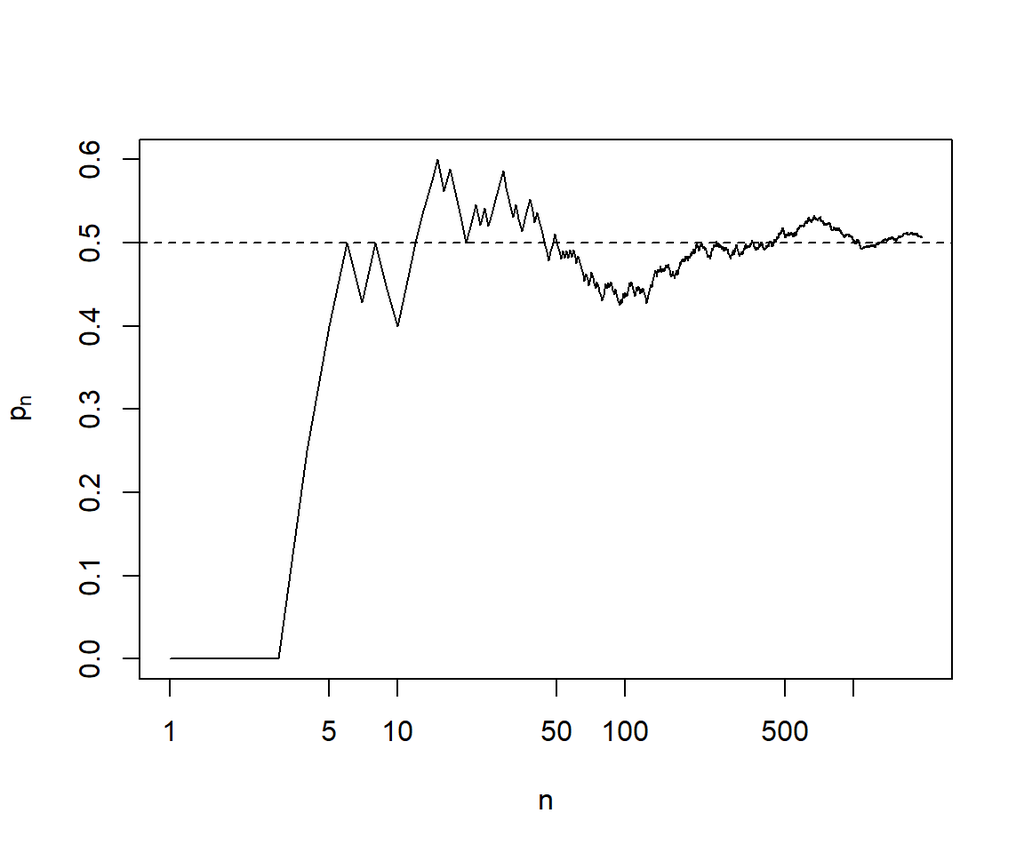

(O eixo horizontal está na escala log).

## Definições

- **Espaço Amostral**: Todos os possíveis resultados de um experimento.
- **Evento**: Qualquer subconjunto do espaço amostral.

Nós conduzimos o experimento $n$ vezes. Seja $\#(A)$ o numero de vezes que observamos o evento $A$.

- **Probabilidade empírica** do evento $A$:
  $$p_n(A)=\frac{\#(A)}{n}.$$
- **Probabilidade teórica** do evento $A$:
  $$P(A)=\lim_{n\to\infty}p_n(A)$$
- Nota: $0\leq P(A)\leq 1$.

## Probabilidades teóricas de dois eventos

- Se dois eventos $A$ e $B$ são **disjuntos** (sem intersecção) então
  - $\#(A \text{e} B) = 0$ implica que $P(A \cap B)=0.$
  - $\#(A \text{ou} B)=\#(A)+\#(B)$ implica que $P(A \cup B)=P(A)+P(B).$

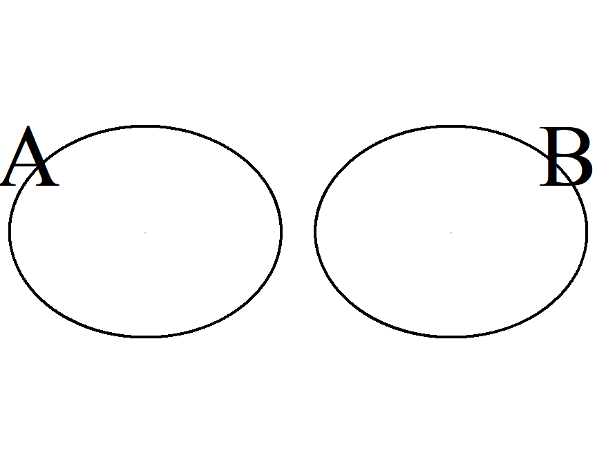

- Se dois eventos $A$ e $B$ **não são disjuntos** então a fórmula mais geral é
  $$P(A \cup B) = P(A) + P(B) - P(A \cap B).$$

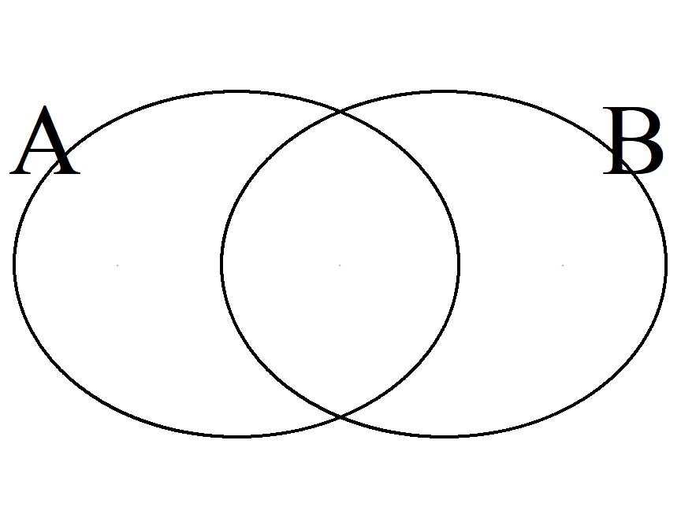

## Probabilidade Condicional

- Digamos que consideramos dois eventos $A$ e $B$. Então a **probabilidade condicional** de $A$ dado (ou condicional ao) o evento $B$ é escrito $P(A \mid B)$ e é definido por
  $$P(A \mid B)=\frac{P(A \cap B)}{P(B)}.$$
- A probabilidade acima pode ser entendida do seguinte modo: “quão provável é o evento $A$ se nós sabemos que $B$ ocorreu”.

### Exemplo com os dados das revistas:

```r
magAds <- read.delim("C:/Users/fsabino/Desktop/Codes/papers/Introductory_Stat_I/notebook/datasets_ads.txt")

# Criando dois novos fatores: 'words' e 'education':
magAds$words <- cut(magAds$WDS, breaks = c(31, 72, 146, 230), include.lowest = TRUE)
magAds$education <- factor(magAds$GROUP, levels = c(1, 2, 3), labels = c("high", "medium", "low"))

library(mosaic)
tab <- tally( ~ words + education, data = magAds)
tab
```

```
##            education
## words       high medium low
##   [31,72]      4      6   5
##   (72,146]     5      6   8
##   (146,230]    9      6   5
```

- O evento $A$=$\{$words=(146,230]$\}$ (o anúncio é um texto “difícil”) tem probabilidade empírica
  $$p_n(A) = \frac{9 + 6 + 5}{54} = \frac{20}{54} \approx 37 \%.$$
- Digamos que só estamos interessados na probabilidade de um texto “difícil” (evento $A$) para revistas de educação superior (high education), i.e. condicionando no evento $B=\{$education=high$\}$. Então a probabilidade condicional empírica pode ser calculada a partir da tabela acima:

$$p_n(A \mid B) = \frac{9}{4+5+9} = \frac{9}{18} = 0.5 = 50\%.$$

- A probabilidade condicional de $A$ dado $B$ pode ser (teoricamente) expressada por

$$\begin{aligned}
P(A \mid B)
&= P(\text{words} =(146,230] \mid \text{education = high}) \\[0.5em]
&= \frac{P(\text{words} =(146,230] \text{ and } \text{education = high})}{P(\text{education = high})}, \\
\end{aligned}$$
que traduzindo para probabilidade empíricas (substituindo $P$ por $p_n$) dará

$$\begin{aligned}
p_n(A \mid B)
&= \frac{p_n(\text{words} =(146,230] \text{ and } \text{education = high})}{p_n(\text{education = high})} \\
&= \frac{\frac{9}{54}}{\frac{4+5+9}{54}} \\
&= \frac{9}{4+5+9} \\[0.5em]
&= 50\%
\end{aligned}$$
como calculado acima.

## Probabilidade condicional e independência

- Se a informação sobre $B$ não muda a probabilidade de $A$ nós dizemos que $A$ é **independente** de $B$ e escrevemos
  $$P(A \mid B) = P(A) \quad \Leftrightarrow \quad P(A \cap B) = P(A)P(B)$$
  Quando isto acontecer nós dizemos que $A$ e $B$ são **eventos independentes**.
- Em geral, os eventos $A_1, A_2, ..., A_k$ são independentes se
  $$P(A_1 \cap A_2 \cap ... \cap A_k) = P(A_1) P(A_2) \cdots P(A_k)$$
  e se o produto de todas as combinações de ordem 2 a k-1 também são válidas, i.e., k eventos são ditos independentes se são **independentes k a k, (k-1) a (k-1),…, dois a dois**.

### Magazine data revisited

- Recall the empirical probabilities calculated above:
  $$p_n(A) = 37 \%
  \quad \text{and} \quad
  p_n(A \mid B) = 50\%.$$
- These indicate (we cannot say for sure as we only consider a finite sample - we will later see how to test for this) that the theoretical probability
  $$P(A) \neq P(A \mid B)$$
  and hence that knowledge about $B$ (high education level) may convey information about the probability of $A$ (the ad containing a “difficult” text).

## Discrete distribution

### Example: Magazine data

```r
# Table with the percentage of ads in each combination of the levels of 'words' and 'education'
tab <- tally( ~ words + education, data = magAds, format = "percent")
round(tab, 2) # Round digits
```

```
##            education
## words        high medium   low
##   [31,72]    7.41  11.11  9.26
##   (72,146]   9.26  11.11 14.81
##   (146,230] 16.67  11.11  9.26
```

- The 9 disjoint events above (corresponding to combinations of `words` and `education`) make up the whole sample space for the two variables. The empirical probabilities of each event is given in the table.

### General discrete distribution

- In general:
  - Let $A_1,A_2,\ldots,A_k$ be a subdivision of the sample space into pairwise disjoint events.
  - The probabilities $P(A_1), P(A_2), ..., P(A_k)$ are called a **discrete distribution** and satisfy
    $$\sum_{i=1}^kP(A_i)=1.$$

### Example: 3 coin tosses

- **Random/stochastic variable**: A function $Y$ that translates an outcome of the experiment into a number.
- Possible outcomes in an experiment with 3 coin tosses:
  - 0 heads (TTT)
  - 1 head (HTT, THT, TTH)
  - 2 heads (HHT, HTH, THH)
  - 3 heads (HHH)
- The above events are disjoint and make up the whole sample space.
- Let $Y$ be the number of heads in the experiment: $Y(TTT) = 0, Y(HTT) = 1, \ldots$
- Assume that each outcome is equally likely, i.e. probability 1/8 for each event. Then,
  - $P(\text{no heads}) = P(Y = 0) = P(TTT) = 1/8.$
  - $P(\text{one head}) = P(Y = 1) = P(HTT \text{ or } THT \text{ or } TTH) = P(HTT) + P(THT) + P(TTH) = 3/8.$
  - Similarly for 2 or 3 heads.
- So, the distribution of $Y$ is

| Number of heads, $Y$ | 0 | 1 | 2 | 3 |
| --- | --- | --- | --- | --- |
| Probability | 1/8 | 3/8 | 3/8 | 1/8 |

# Distribution of general random variables

## Probability distribution

- We are conducting an experiment where we make a quantitative measurement $Y$ (a random variable), e.g. the number of words in an ad or the waiting time in a queue.
- In advance there are many possible outcomes of the experiment, i.e. $Y$’s value has an uncertainty, which we quantify by the **probability distribution** of $Y$.
- For any interval $(a, b$), the distribution states the probability of observing a value of the random variable $Y$ in this interval:
  $$P(a<Y<b),\qquad -\infty < a < b < \infty.$$
- $Y$ is **discrete** if we can enumerate all the possible values of $Y$, e.g. the number of words in an ad.
- $Y$ is **continuous** if $Y$ can take any value in a interval, e.g. a measurement of waiting time in a queue.

### Sample

We conduct an experiment $n$ times, where the outcome of the $i$th experiment corresponds to a measurement of a random variable $Y_i$, where we assume

- The experiments are **independent**
- The variables $Y_1,\ldots,Y_n$ have the **same distribution**

## Population parameters

- When the sample size grows, then e.g. the mean of the sample, $\overline{y}$, will stabilize around a fixed value, $\mu$, which is usually unknown. The value $\mu$ is called the **population mean**.
- Correspondingly, the standard deviation of the sample, $s$, will stabilize around a fixed value, $\sigma$, which is usually unknown. The value $\sigma$ is called the **population standard deviation**.
- Notation:
  - $\mu$ (mu) denotes the population mean.
  - $\sigma$ (sigma) denotes the population standard deviation.

| Population | Sample |
| --- | --- |
| $\mu$ | $\overline{y}$ |
| $\sigma$ | $s$ |

### Distribution of a discrete random variable

- Possible values for $Y$: $\{y_1,y_2,\ldots,y_k\}$.
- The **distribution** of $Y$ is the probabilities of each possible value: $p_i=P(Y=y_i), \quad i=1,2,\ldots,k$.
- The distribution satisfies: $\sum_{i=1}^kp_i=1$.

## Expected value (mean) for a discrete distribution

- The **expected value** or **(population) mean** of $Y$ is
  $$\mu = \sum_{i=1}^k y_ip_i$$
- An important property of the expected value is that it has the same unit as the observations (e.g. meter).

### Example: number of heads in 3 coin flips

- Recall the distribution of $Y$ (number of heads):

  | y (number of heads) | 0 | 1 | 2 | 3 |
  | --- | --- | --- | --- | --- |
  | $P(Y = y)$ | 1/8 | 3/8 | 3/8 | 1/8 |

- Then the expected value is

$$\mu = 0\frac{1}{8}+1\frac{3}{8}+2\frac{3}{8}+3\frac{1}{8}=1.5.$$

*Note that the expected value is not a possible outcome of the experiment itself.*

## Variance and standard deviation for a discrete distribution

- The **(population) variance** of $Y$ is
  $$\sigma^2 = \sum_{i=1}^k (y_i - \mu)^2 p_i$$
- The **(population) standard deviation** is $\sigma = \sqrt{\sigma^2}$.
- Note: If the observations have unit meter, the **variance** has unit $\text{meter}^2$ which is hard to interpret. The **standard deviation** on the other hand has the same unit as the observations (e.g. meter).

### Example: number of heads in 3 coin flips

The distribution of the random variable ‘number of heads in 3 coin flops’ has variance
$$\sigma^2
= (0-1.5)^2\frac{1}{8} + (1-1.5)^2\frac{3}{8} + (2-1.5)^2 \frac{3}{8} + (3-1.5)^2 \frac{1}{8} = 0.75.$$

and standard deviation
$$\sigma = \sqrt{\sigma^2} = \sqrt{0.75} = 0.866.$$

## The binomial distribution

- The **binomial distribution** is a discrete distribution
- The distribution occurs when we conduct a success/failure experiment $n$ times with probability $\pi$ for success. If $Y$ denotes the number of successes it can be shown that
  $$p_Y(y) = P(Y = y) = \binom{n}{y} \pi^y (1-\pi)^{n-y},$$
  where $\binom{n}{y}=\frac{n!}{y!(n-y)!}$ and $m!$ is the product of the first $m$ integers.
- Expected value: $\mu = n \pi$.
- Variance: $\sigma^2 = n \pi (1-\pi)$.
- Standard deviation: $\sigma = \sqrt{n \pi (1-\pi)}$.

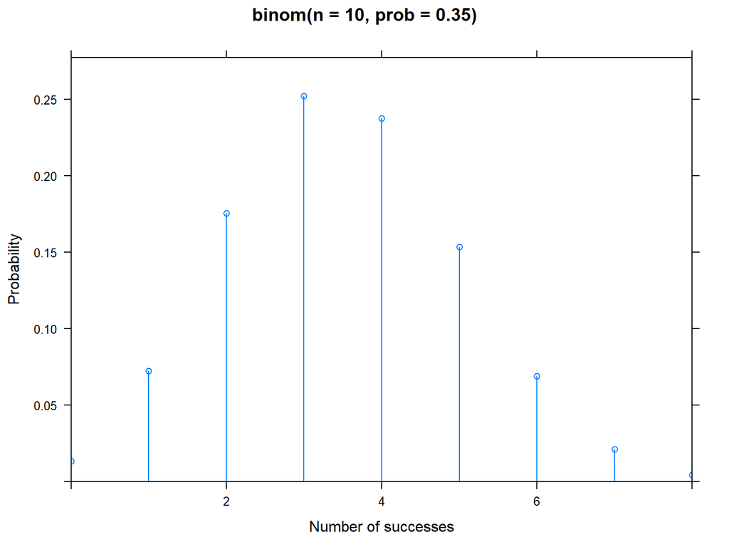

```r
# The binomial distribution with n = 10 and pi = 0.35:
plotDist("binom", size = 10, prob = 0.35,
         ylab = "Probability", xlab = "Number of successes", main = "binom(n = 10, prob = 0.35)")
```

## Distribution of a continuous random variable

- The distribution of a continuous random variable $Y$ is characterized by the so-called probability density function $f_Y$.

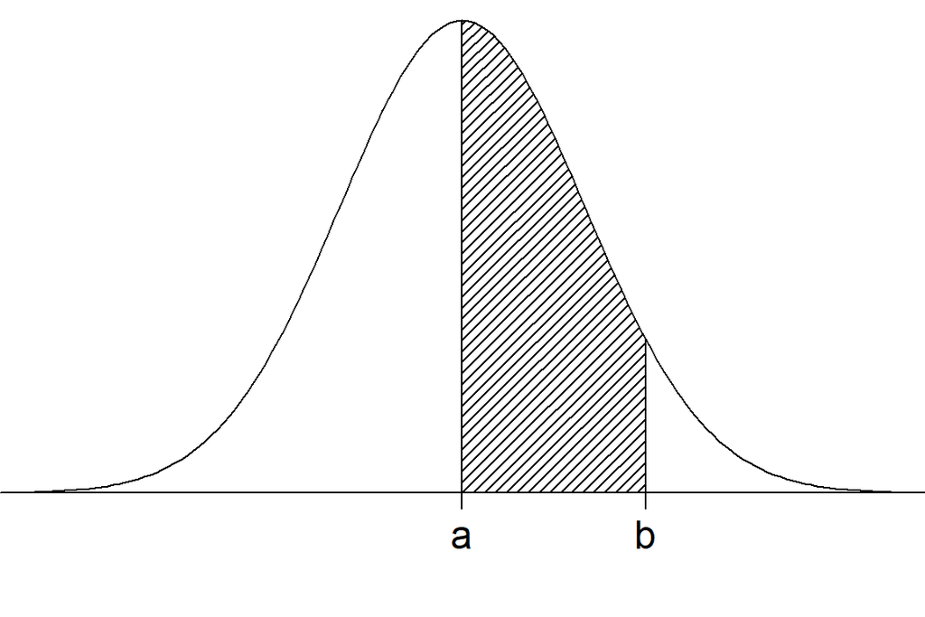

- The area under the graph of the probability density function between $a$ and $b$ is equal to the probability of an observation in this interval.
- $f_Y(y)\geq 0$ for all real numbers $y$.
- The area under the graph for $f_Y$ is equal to 1.
- For example the **uniform distribution** from $A$ to $B$:
  $$f_Y(y)=
  \begin{cases}
  \frac{1}{B-A} & A<y<B \\
  0 & \text{otherwise}
  \end{cases}$$

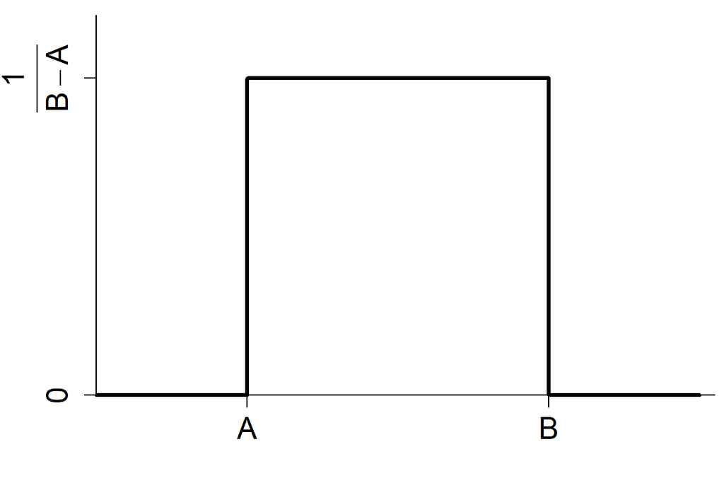

## Density function

### Increasing number of observations

- Another way to think about the density is in terms of the histogram.
- If we draw a histogram for a sample where the area of each box corresponds to the relative frequency of each interval, then the total area will be 1.
- When the number of observations (sample size) increase we can make a finer interval division and get a more smooth histogram.
- We can imagine an infinite number of observations, which would produce a nice smooth curve, where the area below the curve is $1$. A function derived this way is also what we call the **probability density function**.

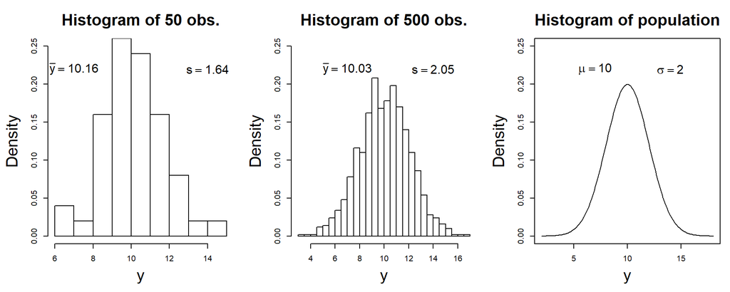

### Density shapes

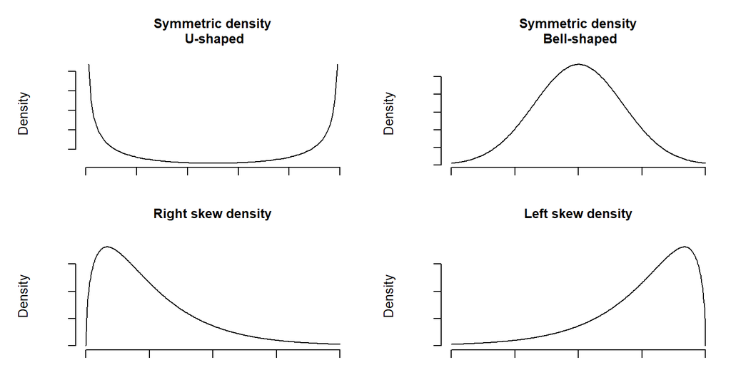

## Normal distribution

- The normal distribution is a continuous distribution determined by two parameters:
  - $\mu$: the **mean** (expected value), which determines where the distribution is centered.
  - $\sigma$: the **standard deviation**, which determines the spread of the distribution about the mean.
- The distribution has a bell-shaped probability density function:
  $$f_Y(y;\mu,\sigma) = \frac{1}{\sqrt{2\pi\sigma^2}}\exp \left (-\frac{1}{2\sigma^2}(y-\mu)^2 \right )$$
- When a random variable $Y$ follows a normal distribution with mean $\mu$ and standard deviation $\sigma$, then we write $Y \sim \texttt{norm}(\mu,\sigma)$.
- We call $\texttt{norm}(0, 1)$ the **standard normal distribution**.

### Reach of the normal distribution

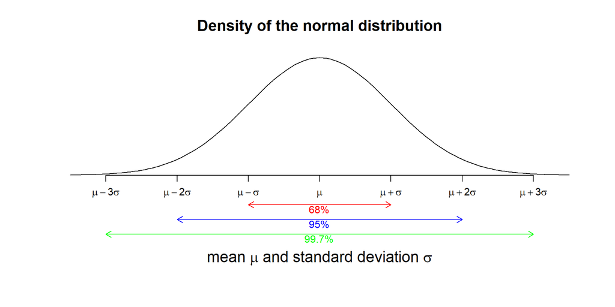

Interpretation of standard deviation:

- $\approx$ 68% of the population is within 1 standard deviation of the mean.
- $\approx$ 95% of the population is within 2 standard deviations of the mean.
- $\approx$ 99.7% of the population is within 3 standard deviations of the mean.

### Normal $z$-score

- If $Y\sim \texttt{norm}(\mu,\sigma)$ then the corresponding $z$-score is
  $$Z=\frac{Y-\mu}{\sigma}=\frac{\mathtt{observation-mean}}{\mathtt{standard\
  deviation}}$$
- I.e. $Z$ counts the number of standard deviations that the observation lies away from the mean, where a negative value tells that we are below the mean.
- We have that $Z\sim \texttt{norm}(0,1)$, i.e. $Z$ has zero mean and standard deviation one.
- This implies that
  - $Z$ lies between $-1$ and $1$ with probability 68%
  - $Z$ lies between $-2$ and $2$ with probability 95%
  - $Z$ lies between $-3$ and $3$ with probability 99.7%
- It also implies that:
  - The probability of $Y$ being between $\mu - z\sigma$ and $\mu + z\sigma$ is equal to the probability of $Z$ being between $-z$ and $z$.

### Calculating probabilities in the standard normal distribution

- The function `pdist` always outputs the area to the left of the $z$-value (quantile/percentile) we give as input (variable `q` in the function), i.e. it outputs the probability of getting a value less than $z$. The first argument of `pdist` denotes the distribution we are considering.

```r
# For a standard normal distribution the probability of getting a value less than 1 is:
left_prob <- pdist("norm", q = 1, mean = 0, sd = 1)
```

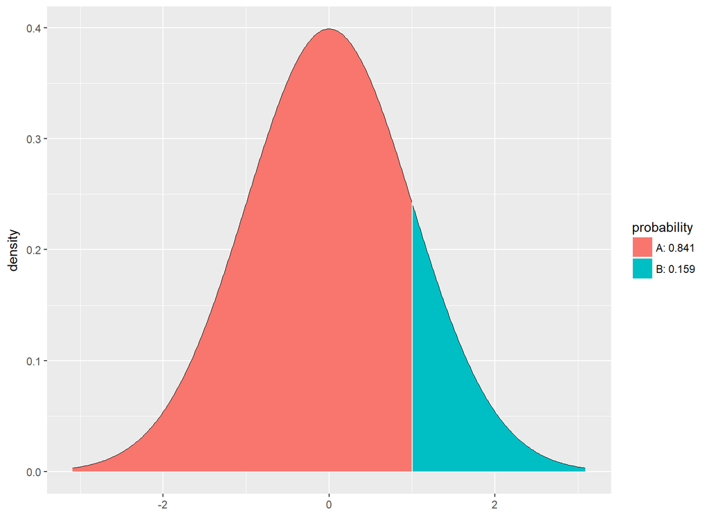

```r
left_prob
```

```
## [1] 0.8413447
```

- Here there is a conflict between **R** and the textbook, since in the book we always consider right probabilities in the normal distribution. Since the total area is 1 and we have the left probability we easily get the right probability:

```r
right_prob <- 1 - left_prob
right_prob
```

```
## [1] 0.1586553
```

- For $z=1$ we have a right probability of $p=0.1587$, so the probability of an observation between $-1$ and $1$ is $1 - 2 \cdot 0.1587 = 0.6826 = 68.26\%$ due to symmetry.

### Calculating $z$-values (quantiles) in the standard normal distribution

- If we have a probability and want to find the corresponding $z$-value we again need to decide on left/right probability. The default in **R** is to find the left probability, so if we want the $z$-value with e.g. 0.5% probability to the left we get:

```r
left_z <- qdist("norm", p = 0.005, mean = 0, sd = 1, xlim = c(-4, 4))
```

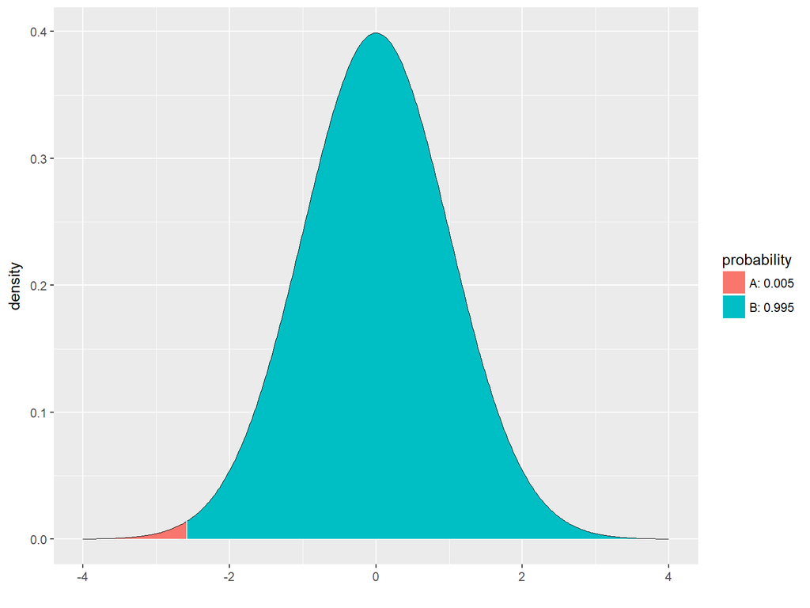

```r
left_z
```

```
## [1] -2.575829
```

- However, in all the formulas in the course we follow the textbook and consider $z$-values for a given right probability. E.g. with 0.5% probability to the right we get:

```r
right_z <- qdist("norm", p = 1-0.005, mean = 0, sd = 1, xlim = c(-4, 4))
```

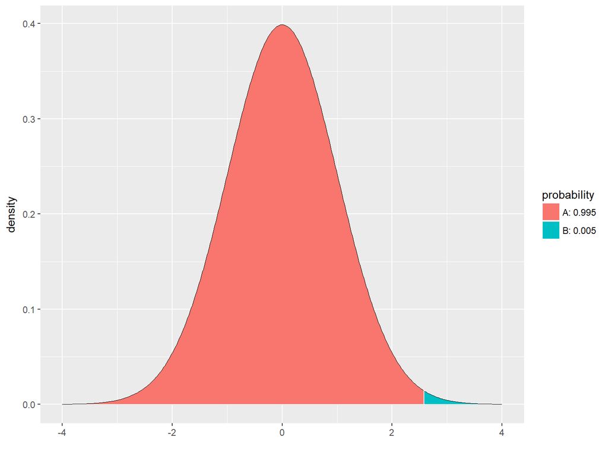

```r
right_z
```

```
## [1] 2.575829
```

- Thus, the probability of an observation between $-2.576$ and $2.576$ equals $1 - 2 \cdot 0.005 = 99\%$.

### Example

The Stanford-Binet Intelligence Scale is calibrated to be approximately normal with mean 100 and standard deviation 16.

What is the 99-percentile of IQ scores?

- The corresponding $z$-score is $Z=\frac{IQ-100}{16}$, which means that $IQ=16Z+100$.
- The 99-percentile of $z$-scores has the value 2.326 (can be calculated using `qdist`).
- Then, the 99-percentile of IQ scores is:
  $$IQ=16\cdot 2.326+100=137.2.$$
- So we expect that one out of hundred has an IQ exceeding 137.

# Distribution of sample statistic

## Estimates and their variability

We are given a sample $y_1,y_2,\ldots,y_n$.

- The sample mean $\bar{y}$ is the most common estimate of the population mean $\mu$.
- The sample standard deviation, $s$, is the most common estimate of the population standard deviation $\sigma$.

We notice that there is an uncertainty (from sample to sample) connected to these statistics and therefore we are interested in describing their **distribution**.

## Distribution of sample mean

- We are given a sample $y_1,y_2,\ldots,y_n$ from a population with mean $\mu$ and standard deviation $\sigma$.
- The sample mean
  $$\bar{y}=\frac{1}{n}(y_1+y_2+\ldots+y_n)$$
  then has a distribution where
  - the distribution has mean $\mu$,
  - the distribution has standard deviation $\frac{\sigma}{\sqrt{n}}$ (also called the **standard error**), and
  - when $n$ grows, the distribution approaches a normal distribution. This result is called **the central limit theorem**.

### Central limit theorem

- The points above can be summarized as
  $${\bar{y}}\approx
  \texttt{norm}(\mu,\frac{\sigma}{\sqrt{n}})$$
  i.e. $\bar{y}$ is approximately normally distributed with mean $\mu$ and standard error $\frac{\sigma}{\sqrt{n}}$.
- When our sample is sufficiently large (such that the above approximation is good) this allows us to make the following observations:
  - We are $95\%$ certain that $\bar{y}$ lies in the interval from $\mu-2\frac{\sigma}{\sqrt{n}}$ to $\mu+2\frac{\sigma}{\sqrt{n}}$.
  - We are almost completely certain that $\bar{y}$ lies in the interval from $\mu-3\frac{\sigma}{\sqrt{n}}$ to $\mu+3\frac{\sigma}{\sqrt{n}}$.
- This is not useful when $\mu$ is unknown, but let us rephrase the first statement to:
  - We are $95\%$ certain that $\mu$ lies in the interval from $\bar{y}-2\frac{\sigma}{\sqrt{n}}$ to $\bar{y}+2\frac{\sigma}{\sqrt{n}}$, i.e. we are directly talking about the uncertainty of determining $\mu$.

### Illustration of CLT

The central limit theorem is illustrated in Agresti:

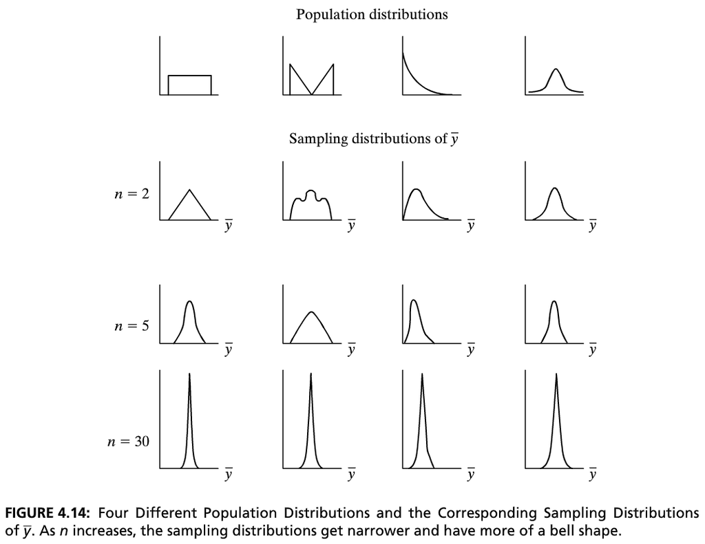

### Example

- Body Mass Index (BMI) of people in Northern Jutland (2010) has mean $\mu=25.8$ kg/$\mathtt{m}^2$ and standard deviation $4.8$ kg/$\mathtt{m}^2$.
- A random sample of $n=100$ costumers at a burger bar had an average BMI given by $\bar{y}=27.2$.
- If “burger bar” has “no influence” on BMI (and the sample is representative of the population/people in Northern Jutland), then
  $$\bar{y} \approx \texttt{norm}(\mu,\frac{\sigma}{\sqrt{n}})=\texttt{norm}(25.8,0.48).$$
- For the actual sample this gives the observed $z$-score
  $$z_{obs}=\frac{27.2-25.8}{0.48}=2.92$$
- Recalling that the $z$-score is (here approximately) standard normal, the probability of getting a higher $z$-score is:

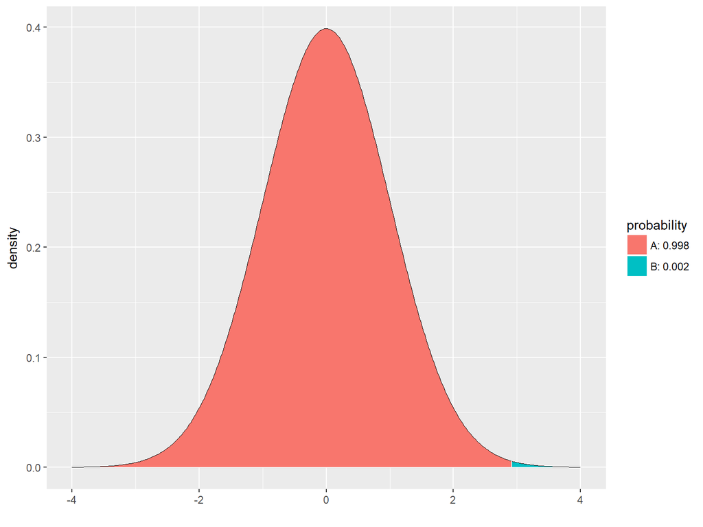

```
## [1] 0.001750157
```

```r
1 - pdist("norm", mean = 0, sd = 1, q = 2.92, xlim = c(-4, 4))
```

- Thus, it is highly unlikely to get a random sample with such a high $z$-score. This indicates that costumers at the burger bar has a mean BMI, which is higher than the population mean.